# Stats 506, Computational Methods and Tools in Statistics - Overview

9/1/2020

## Computatational Methods and Tools in Statistics

- This course take a broad view of computational methods that encompasses the many ways - both routine and specialized - that computers are used by statistical analysts and data scientists.

## Computatational Methods and Tools in Statistics

- This broad view encompasses but is not limited to:
  - Managing, obtaining, and organizing data
  - Data exploration and visualization
  - Using statistical software for data analysis
  - Reproducible reporting and presentation of analyses
  - Computationally intensive methods in statistics and data science

## Course Overview

- Course Website: www.jbhender.github.io/Stats506/F20/
- General computing skills: Linux shell, git, literate programming
- Scripting Languages: R, Stata, SAS
- “Advanced” R: dplyr, data.table, functional and object oriented programming
- Other languages: (R)Markdown, (minimal) html
- High performance, parallel, and batch computing
- Computational algorithms: cross-validation, bootstrap re-sampling, permutation testing, Monte Carlo estimation, and simulation studies.

## Canvas

- Recorded lectures, reading assignments, quizzes, and surveys
- There is a “Computing Experience” survey due this Thursday.
- The quiz for the first module, Linux Shell Skills, is due next Tuesday.
- New modules, with lectures, reading assignments and a quiz, will be released on Mondays. The quiz is always due the *following* Tuesday.

## Class meetings

- Beginning September 8, we will use class meetings on Tuesday for a synchronous activity related to the module released the previous week.
- Activities will run each Tuesday until the Thanksgiving recess, with the exception of Tuesday November 3 (US election). This is 10 meetings.
- Attendance on activity Tuesdays is required. Each class counts 10 points (1%) toward the course grade.
- Class meetings on Thursdays and Tuesdays after the Thanksgiving recess will be brief Q & A sessions.

## Optional Texts

- There are three optional texts for this course, all on using R.
- None of texts are required to complete problem sets or quizzes, but I will occasionally include optional readings from these texts to supplement course material.
- *The Art of R Programming*, by Norman Matloff, is recommended for those with little to no previous experience in R.
- [R for Data Science](http://r4ds.had.co.nz/) by Garrett Grolemund, and Hadley Wickham is a useful read for both new and experienced R users and will be a frequent reference for this course.
- [Advanced R](https://adv-r.hadley.nz/), by Hadley Wickham, is for those who would like to develop a deep understanding of R and its inner workings.

## Statistical Software

- Why will we focus on R, SAS, and Stata?
- These appear to be the most in demand in the job market for statistical analysts.
- For data science jobs, R and Python appear to be the most in demand.
- Other courses devoted exclusively to Python.

## Software Popularity

- In [The Popularity of Data Science Software](http://r4stats.com/articles/popularity/), Robert Muenchen presents analyses measuring the popularity of various software in job postings and academic articles.
- We will review the first 5 or so plots from the article.

## Health Services Research

- In health services research a large majority of academic articles use SAS or Stata [(Dembe, et al; 2011)](https://www.ncbi.nlm.nih.gov/pmc/articles/PMC3205033/?report=classic)

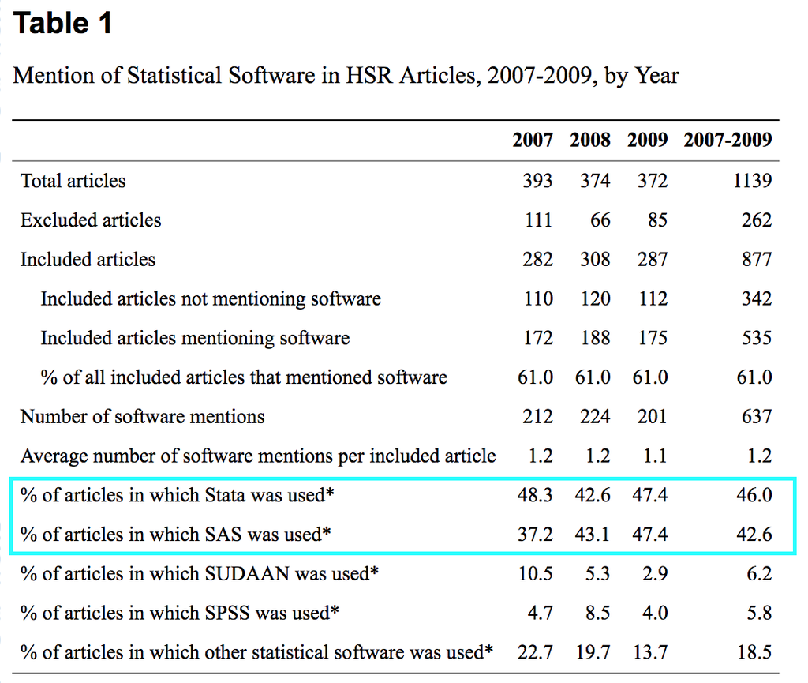

## About (some of) these languages

- R, SAS, and Stata are examples of domain specific languages used primarily for statistics and data analysis.
- SQL or ‘structured query language’ is a specialized language for querying databases.
- Python is a general purpose scripting language with a number of libraries for math, statistics, data analysis, and machine learning including: numpy, pandas, statsmodels, sckitlearn, and tensorflow.
- System and application languages such as C/C++, Java, and go can be used to produce very high performance code – but have a larger learning and development curve.